# Discussion

Victor Ordu

13 June 2016

I will attempt to give highlights of the approach I used in conducting the multivariate analysis of the data as proposed.

**Fitting a regression model for the data** Declare composite formula for the models that we will be fitting that contains the various outcome-predictor pairs on the left and right hand side, respectivel7

```
## concern.stress | concern.bullying | concern.violence ~ risks.time +
##     risks.communication + risks.lackemployeecontrol + risks.unclearPolicy +
##     risks.workinghours | risks.poor.cooperation + risks.jobinsecurity +
##     risks.difficultpeople + risks.relationships + risks.discrimination
```

```
## concern.stress ~ risks.time + risks.communication + risks.lackemployeecontrol +
##     risks.unclearPolicy + risks.workinghours
```

This process will be repeated for each step of the analysis as the appropriate pair of outcome/predictors are selected.

```
## Call:
## polr(formula = theFORMULA, data = mydata, Hess = TRUE)
##
## Coefficients:
##                                Value Std. Error t value
## risks.timeNo                -0.53481    0.06150 -8.6955
## risks.communicationNo        0.01709    0.05900  0.2896
## risks.lackemployeecontrolNo -0.24134    0.05806 -4.1564
## risks.unclearPolicyNo       -0.04515    0.05857 -0.7709
## risks.workinghoursNo        -0.27399    0.05734 -4.7781
##
## Intercepts:
##                            Value    Std. Error t value
## No concern|Some concern     -5.9709   0.1868   -31.9578
## Some concern|Major concern   0.0974   0.0564     1.7256
##
## Residual Deviance: 8060.392
## AIC: 8074.392
```

There are a few lines of code that will allow us to print the p-values from this summary of the model.

After removing the predictors that were not significant contributors to the fit,

```
##                                  Value Std. Error    t value       p-value
## risks.timeNo                -0.5369504 0.05790191  -9.273450  1.802196e-20
## risks.lackemployeecontrolNo -0.2446466 0.05657628  -4.324190  1.530934e-05
## risks.workinghoursNo        -0.2793714 0.05646470  -4.947717  7.508893e-07
## No concern|Some concern     -5.9654993 0.18614302 -32.047935 2.345664e-225
## Some concern|Major concern   0.1006677 0.05462897   1.842753  6.536514e-02
```

```
##                                  O.R.     2.5 %    97.5 %
## risks.timeNo                0.5845281 0.5218395 0.6548148
## risks.lackemployeecontrolNo 0.7829812 0.7007614 0.8747717
## risks.workinghoursNo        0.7562590 0.6770179 0.8447619
```

Now, the effects of this model are displayed (with focus on the predictors that were found to significantly contribute to the regression of the outcome variable)

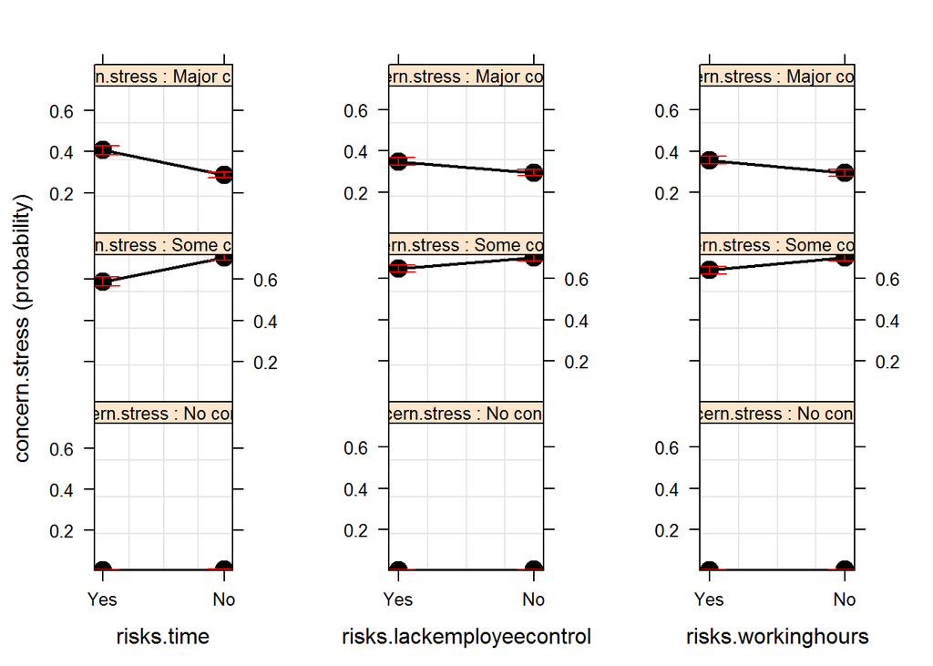

```
##   risks.time risks.lackemployeecontrol risks.workinghours  No concern
## 1        Yes                       Yes                Yes 0.002559197
## 2         No                        No                 No 0.007358372
## 3        Yes                       Yes                Yes 0.002559197
## 4         No                        No                 No 0.007358372
## 5        Yes                       Yes                Yes 0.002559197
## 6         No                        No                 No 0.007358372
##   Some concern Major concern
## 1    0.5225865     0.4748543
## 2    0.7542715     0.2383701
## 3    0.5225865     0.4748543
## 4    0.7542715     0.2383701
## 5    0.5225865     0.4748543
## 6    0.7542715     0.2383701
```

```
##   risks.time risks.lackemployeecontrol risks.workinghours   category
## 1        Yes                       Yes                Yes No concern
## 2         No                        No                 No No concern
## 3        Yes                       Yes                Yes No concern
## 4         No                        No                 No No concern
## 5        Yes                       Yes                Yes No concern
## 6         No                        No                 No No concern
##   probability
## 1 0.002559197
## 2 0.007358372
## 3 0.002559197
## 4 0.007358372
## 5 0.002559197
## 6 0.007358372
```

The same method is now applied in running all the analyses by fitting the model to the variables. (The table were trimmed of predictors that appeared to have the least effect on the outcome variable)

```
##                                 Value Std. Error    t value       p-value
## risks.timeNo               -0.8079453 0.06361174 -12.701198  5.823117e-37
## risks.workinghoursNo       -0.4965951 0.06251004  -7.944246  1.953759e-15
## No concern|Some concern    -6.3968487 0.20606222 -31.043288 1.405491e-211
## Some concern|Major concern  0.4978716 0.05501435   9.049850  1.431645e-19
```

```
##                           O.R.     2.5 %    97.5 %
## risks.timeNo         0.4457731 0.3938459 0.5054050
## risks.workinghoursNo 0.6085994 0.5385229 0.6880816
```

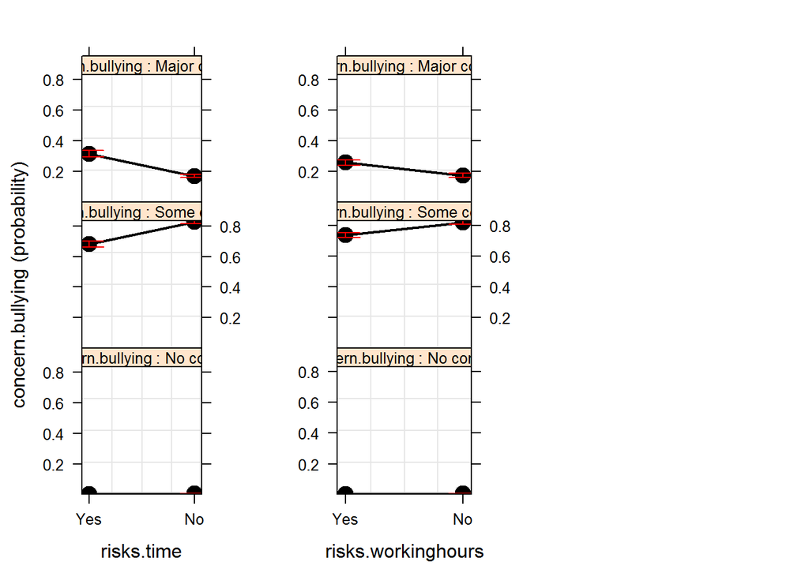

```
##                                 Value Std. Error    t value       p-value
## risks.workinghoursNo       -0.2740444 0.05750017  -4.765976  1.879418e-06
## No concern|Some concern    -5.3919854 0.17790650 -30.307973 9.000494e-202
## Some concern|Major concern  0.8985147 0.04131677  21.746973 7.379140e-105
```

```
##             O.R.
## 2.5 %  0.7602983 0.6792323
## 97.5 % 0.7602983 0.8509766
```

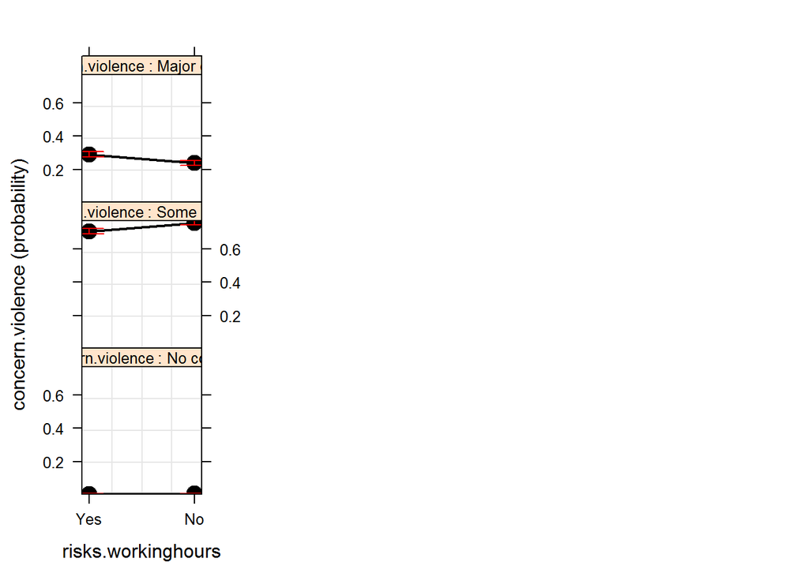

```
##                                 Value Std. Error    t value       p-value
## risks.poor.cooperationNo   -0.2703903 0.05678767  -4.761427  1.922286e-06
## risks.jobinsecurityNo      -0.2791929 0.05574976  -5.007967  5.500805e-07
## risks.relationshipsNo      -0.2004093 0.05772980  -3.471505  5.175494e-04
## No concern|Some concern    -5.6862746 0.18332093 -31.018142 3.069450e-211
## Some concern|Major concern  0.3481302 0.04765512   7.305200  2.768537e-13
```

```
##                               O.R.     2.5 %    97.5 %
## risks.poor.cooperationNo 0.7630816 0.6826872 0.8529164
## risks.jobinsecurityNo    0.7563940 0.6780236 0.8436496
## risks.relationshipsNo    0.8183957 0.7308561 0.9164752
```

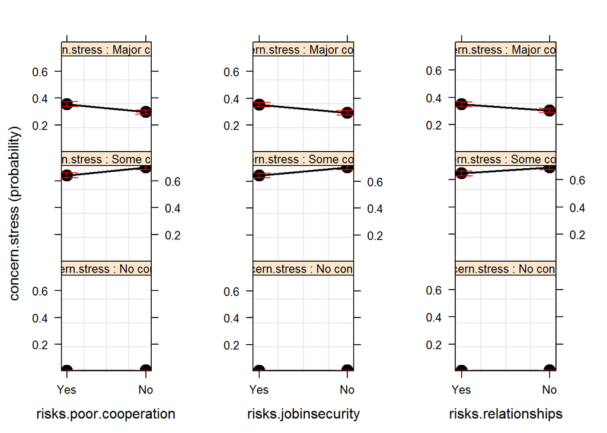

```
##                                 Value Std. Error   t value       p-value
## risks.difficultpeopleNo    -0.1682969 0.06081166  -2.76751  5.648632e-03
## No concern|Some concern    -5.5654094 0.19948343 -27.89911 2.735537e-171
## Some concern|Major concern  1.1780357 0.04334879  27.17575 1.256925e-162
```

```
##             O.R.
## 2.5 %  0.8451029 0.7501162
## 97.5 % 0.8451029 0.9520706
```

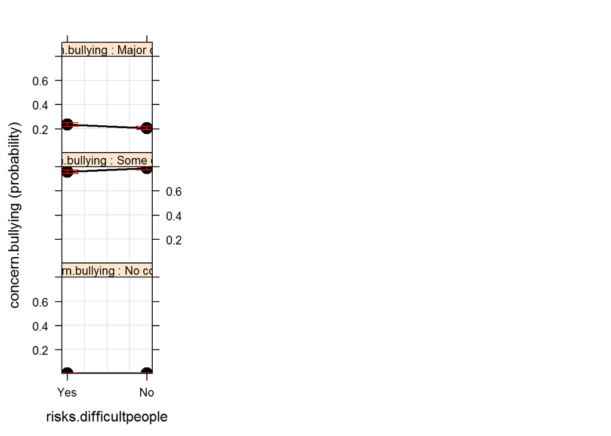

```
##                                 Value Std. Error    t value       p-value
## risks.relationshipsNo      -0.3370920 0.05762614  -5.849637  4.926459e-09
## No concern|Some concern    -5.4375301 0.17827580 -30.500664 2.553603e-204
## Some concern|Major concern  0.8596414 0.04191985  20.506788  1.872613e-93
```

```
##             O.R.
## 2.5 %  0.7138431 0.6375801
## 97.5 % 0.7138431 0.7991870
```

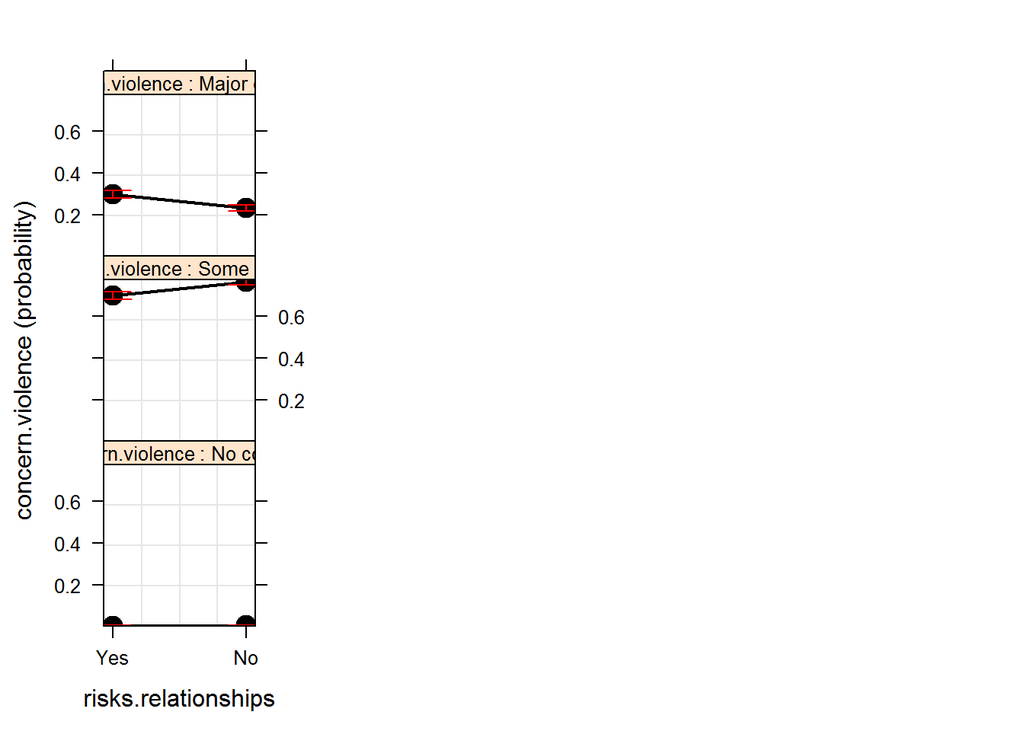

Here is a summary of the interactions among the outcomes and their predictors:

### Significance of predictors (p < .001)

### Organisational factors

| Org. factors | Stress | Bullying | Violence |
| --- | --- | --- | --- |
| Time | Yes | Yes | No |
| Communication | No | No | No |
| Lack Emp cont | Yes | No | No |
| Unclear Pol | No | No | No |
| Working hrs | **Yes** | **Yes** | **Yes** |

### Employee-related issues

[output not shown]

From the model, long working hours seemed to be most significant among the variables in predicting the psychosocial problems of stress, bullying and violence in the workplace.

We now display how well the model will predict the outcomes for organisational factors and employee-related issues, respectively.

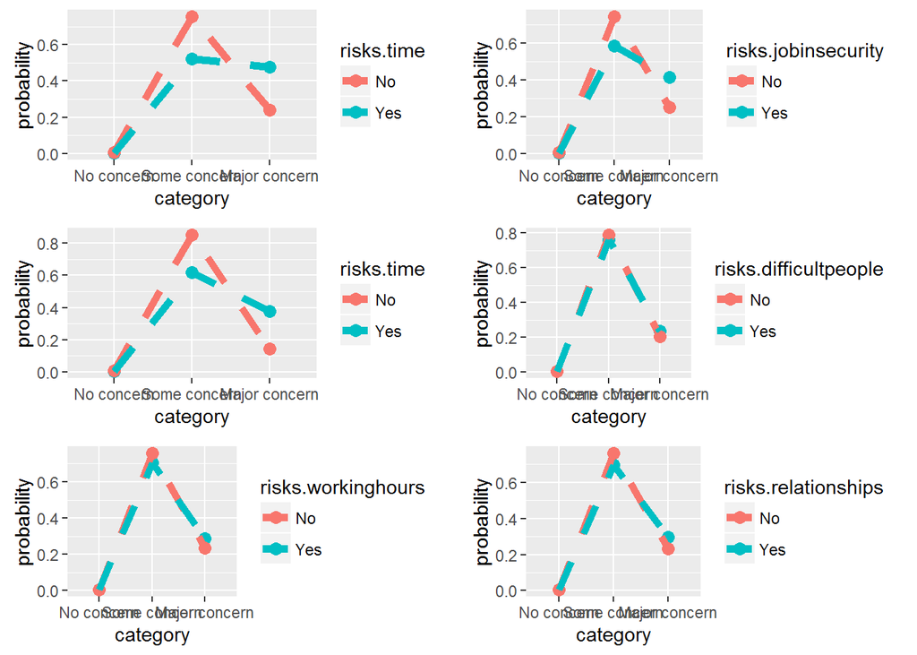